# Ocean pH

K. Dorheim

September 14, 2017

# House Keeping Notes

#### To Do List

- Basin analysis (in progress about half way done)
- Amplitudes/trends in basins
- Detrend the stuff by model/normalize (in progress trying to determine the methodology)
- Add pCO2
- Keeling Curve vs. pH (low)
- Model Amplitude - make a summary table for the document and a separate document for all figures
- Break up into Marine Ecological Units ?
- Figure out better way to print (low priority)
- Ocean Data View ?

#### Next Steps

- Diagnosis peak
- Future and past phase shift
- Signal processing EOF analysis??
- Kanban organization

#### Organization

- September: basin stuff done
- October: outline/story board
- November:
- December: no one is here
- Jan: donish finishing touches on stuff
- Feb: Oceans meeting

# Methodology

Only the annual data sets for pH, check the other variables has depth information so did not average depth for surface values.

#### L1

1. CDO - Concatenate cmip netcdfs and convert to absolute time
2. CDO - Get the field weighted mean via cdo
3. R - Remove model with unrealistic or missing pH/CO3 observations
4. R - Plot monthly weighted mean

# 1. pH

### Files Processed

#### Monthly pH netcdfs

Number of files with depth information.

```
## [1] "None."
```

Number summary of the CMIP5 files found on pic vs. the netcdfs processed by the cdo commands.

|  | number of files | model | domain | variable | experiment | ensemble |
| --- | --- | --- | --- | --- | --- | --- |
| CMIP5 files found | 40 | 14 | 1 | 1 | 2 | 1 |
| CMIP5 processed | NA | 14 | NA | 1 | 2 | 1 |

Summary of the CMIP5 files processed by the cdo commands.

| ensemble | historical | rcp85 |
| --- | --- | --- |
| r1i1p1 | 14 | 14 |

Unprocessed CMIP5 files

```
## [1] "No files identified were unprocessed"
```

### Exploratory Figures

Important Note: None of this figures include data from the *MRI-ESM1* model, pH is unrealistic.

### 1. a. Time Series

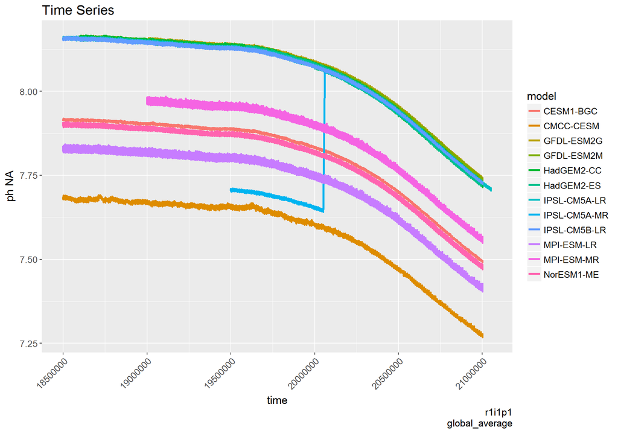

### 1. b. Mean Monthly pH by Model

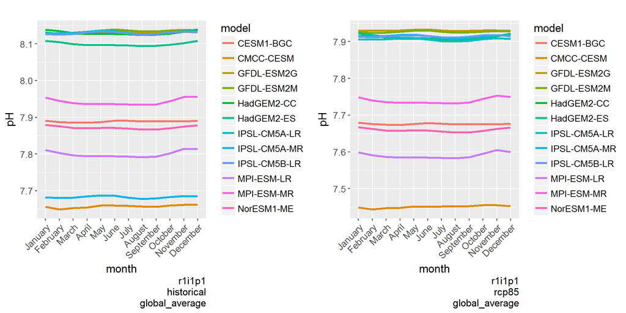

### 1. c. Mean Monthly

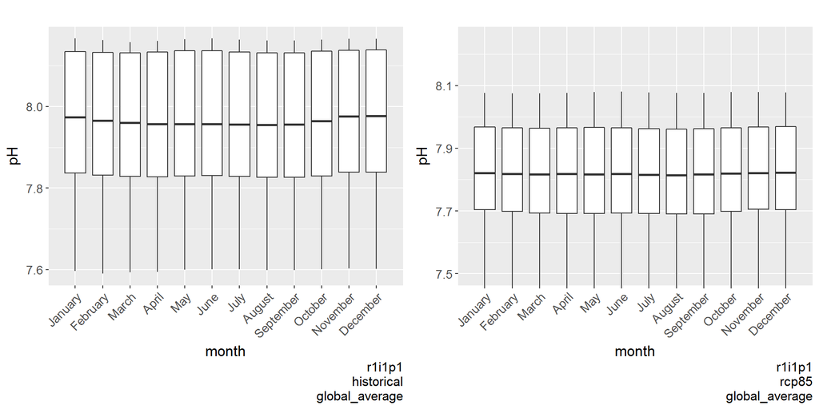

## CESM pH figs

### 1. d. CESM pH time series

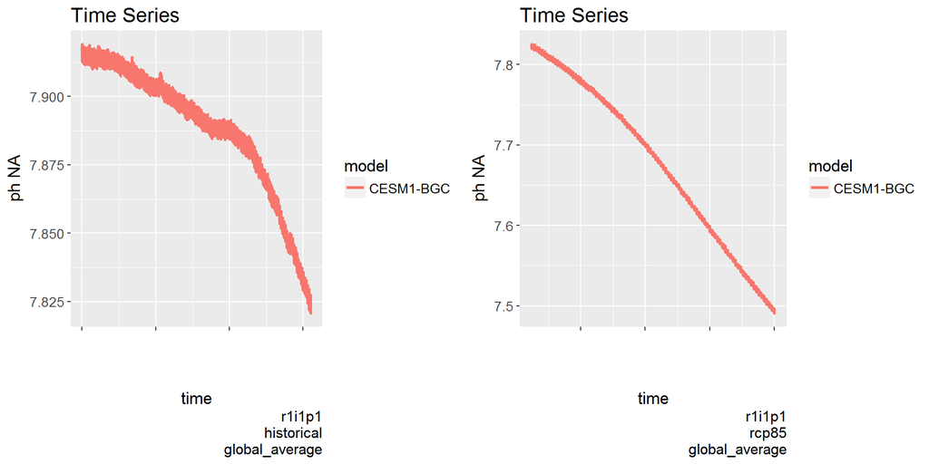

### 1. e. CESM pH monthly time series

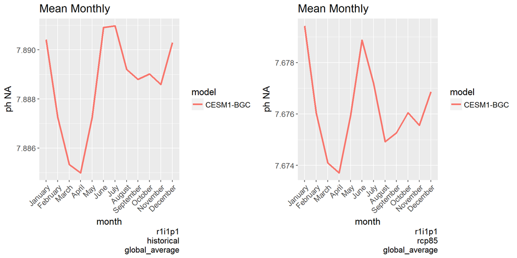

### 1. f. CESM pH boxplot

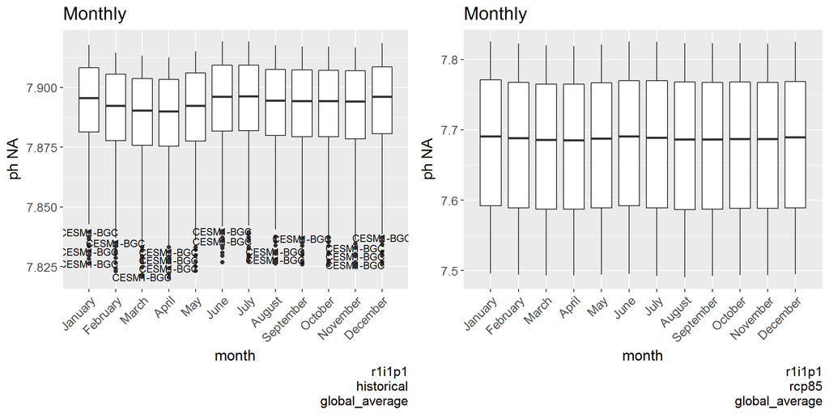

# 2. CO3

### Files Processed

#### Monthly CO3 netcdfs

Number of files with depth information.

```
## [1] "None."
```

Number summary of the CMIP5 files found on pic vs. the netcdfs processed by the cdo commands.

|  | number of files | model | domain | variable | experiment | ensemble |
| --- | --- | --- | --- | --- | --- | --- |
| CMIP5 files found | 66 | 12 | 1 | 1 | 2 | 1 |
| CMIP5 processed | NA | 12 | NA | 1 | 2 | 1 |

Summary of the CMIP5 files processed by the cdo commands.

| ensemble | historical | rcp85 |
| --- | --- | --- |
| r1i1p1 | 7 | 12 |

Unprocessed CMIP5 files

```
## [1] "No files identified were unprocessed"
```

### 2. a. Time Series

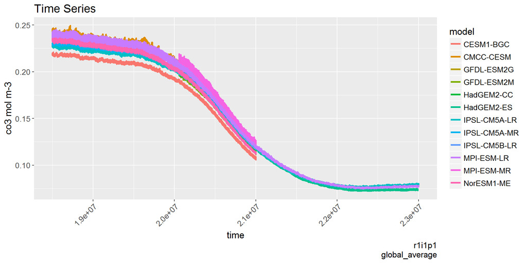

### 2. b. Mean Monthly CO3 by Model

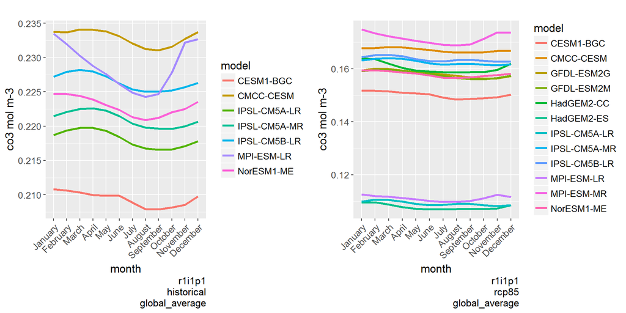

### 2. c. Mean Monthly

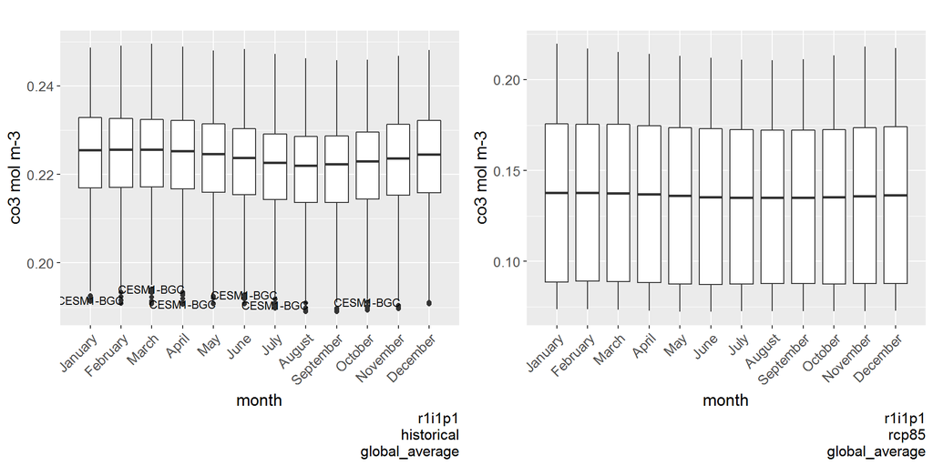

## CESM CO3 figs

### 2. d. CESM CO3 time series

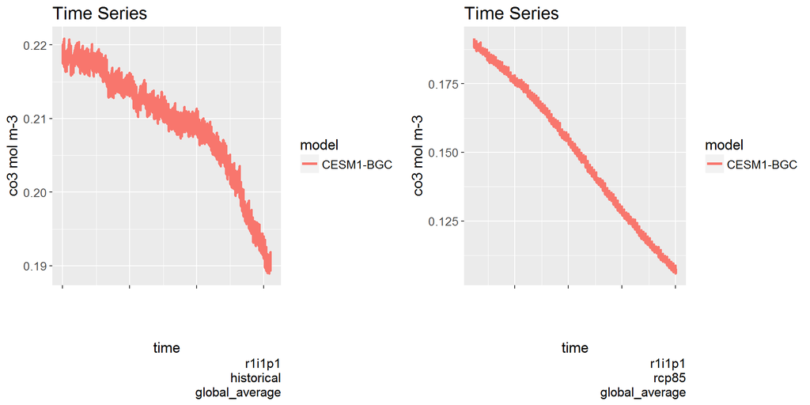

### 2. e. CESM CO3 monthly time series

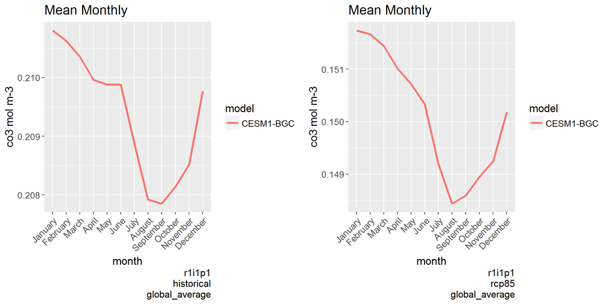

### 2. f. CESM CO3 boxplot

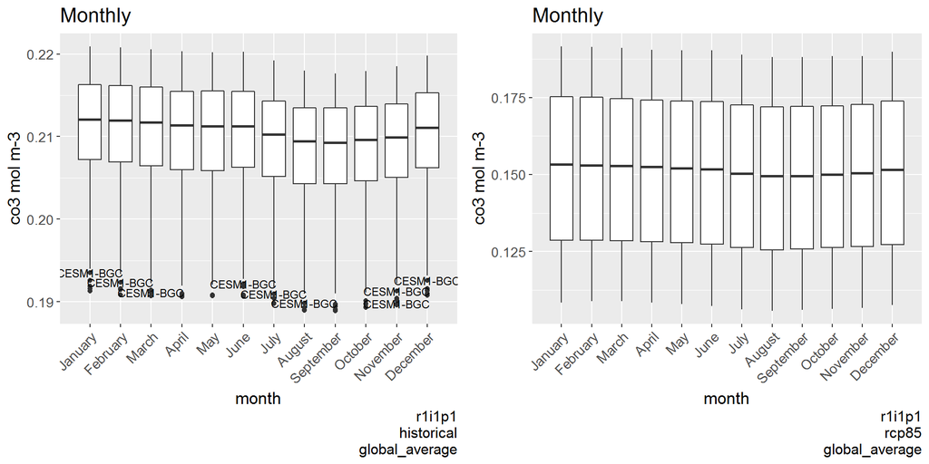

# 3. tos

### Files Processed

#### Monthly tos netcdfs

Number of files with depth information.

```
## [1] "None."
```

Number summary of the CMIP5 files found on pic vs. the netcdfs processed by the cdo commands.

|  | number of files | model | domain | variable | experiment | ensemble |
| --- | --- | --- | --- | --- | --- | --- |
| CMIP5 files found | 260 | 25 | 1 | 1 | 2 | 1 |
| CMIP5 processed | NA | 25 | NA | 1 | 2 | 1 |

Summary of the CMIP5 files processed by the cdo commands.

| ensemble | historical | rcp85 |
| --- | --- | --- |
| r1i1p1 | 17 | 24 |

Unprocessed CMIP5 files

```
## [1] "No files identified were unprocessed"
```

### 3. a. Time Series

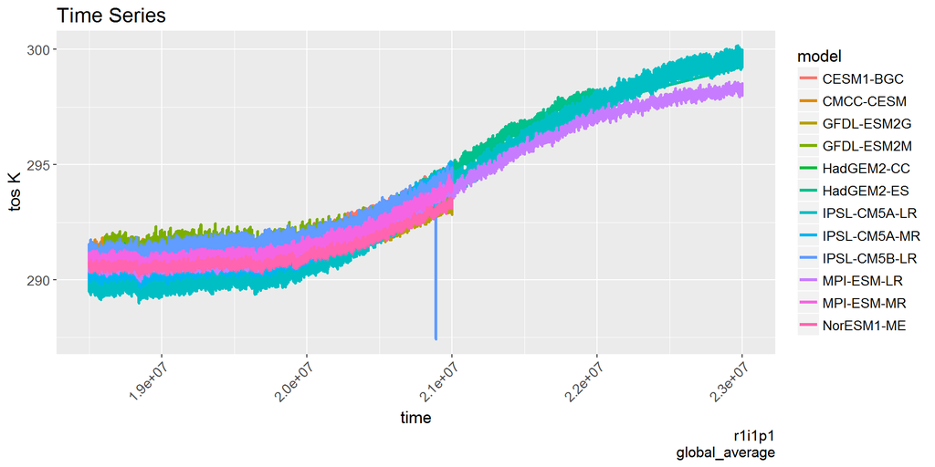

### 3. b. Mean Monthly tos by Model

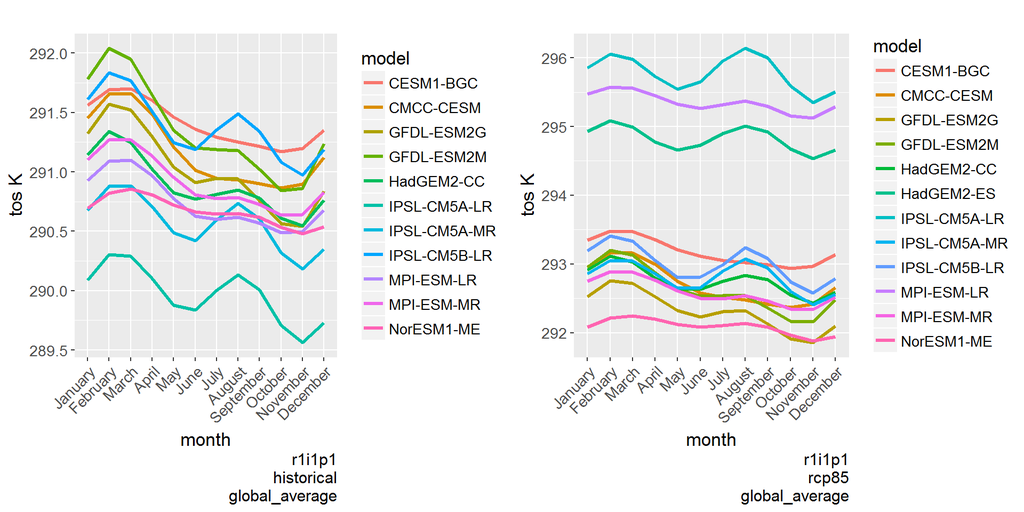

### 3. c. Mean Monthly

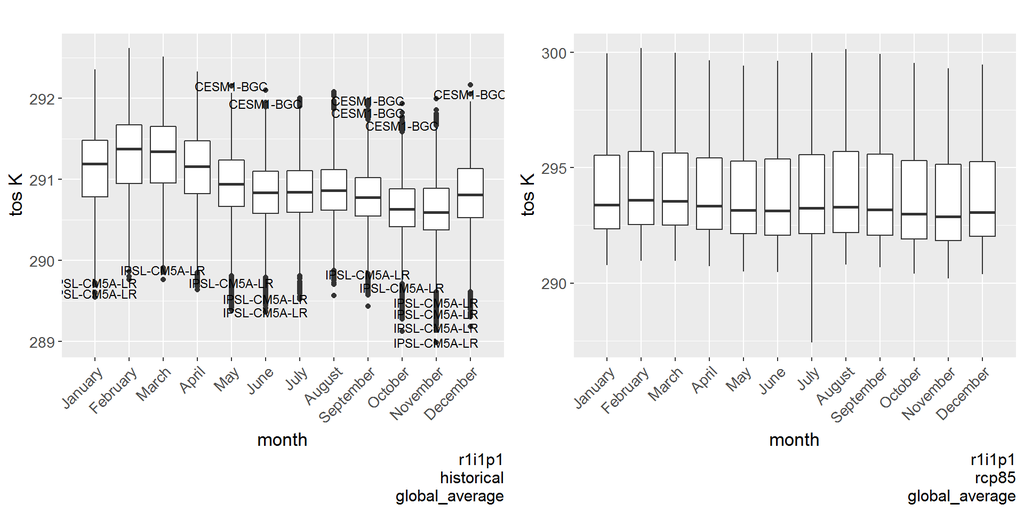

## CESM tos figs

### 3. d. CESM tos time series

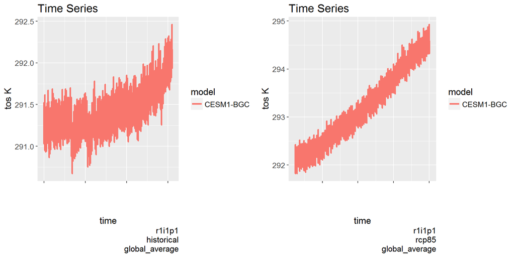

### 3. e. CESM tos monthly time series

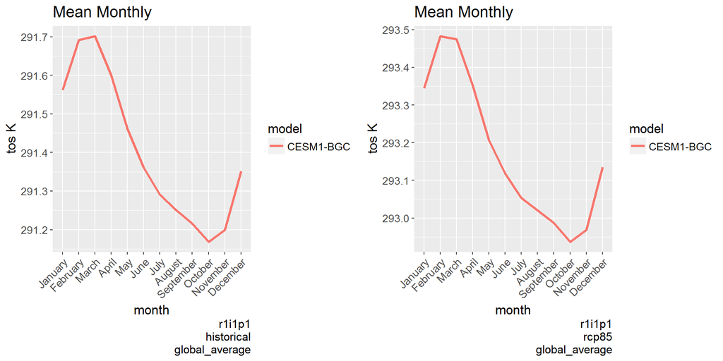

### 3. f. CESM tos boxplot

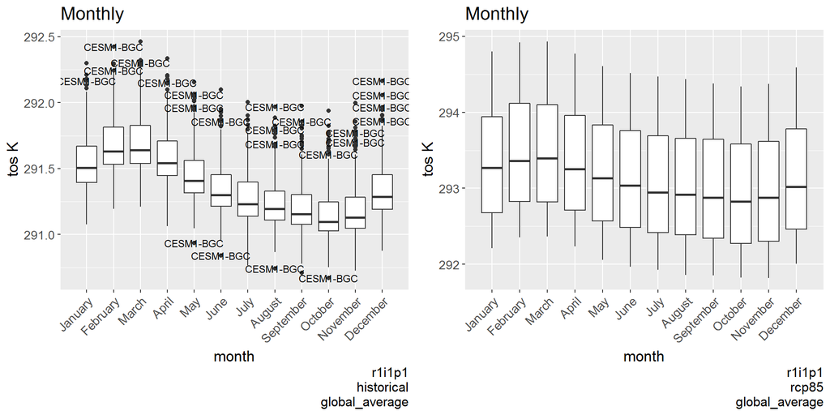

# 4. CESM Monthly Mean and Amplitude

### 4. a. Monthly Mean pH

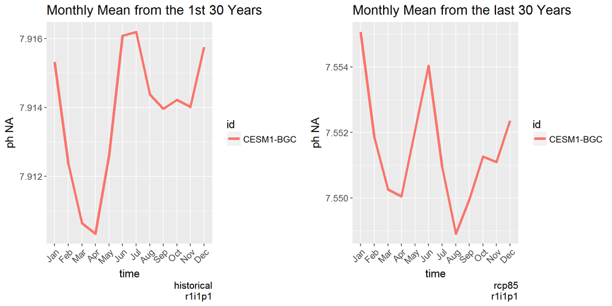

### 4. b. Monthly Amplitude pH

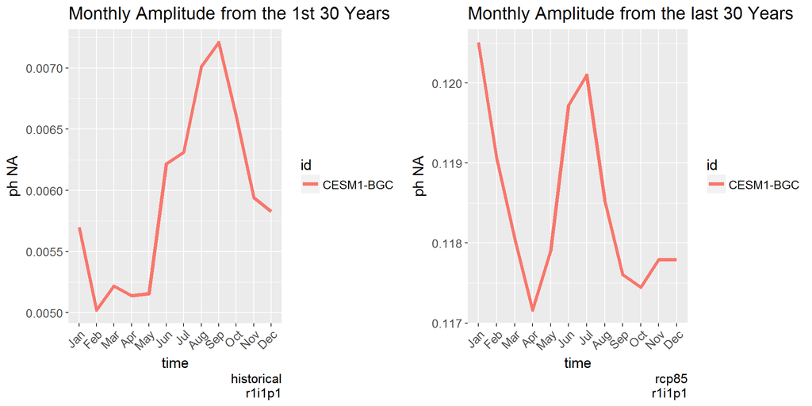

Amplitude mean and sd table

| ensemble | experiment | model | mean | sd |
| --- | --- | --- | --- | --- |
| r1i1p1 | historical | CESM1-BGC | 0.0059474 | 0.0007455 |

| ensemble | experiment | model | mean | sd |
| --- | --- | --- | --- | --- |
| r1i1p1 | rcp85 | CESM1-BGC | 0.1184741 | 0.0011136 |

### 4. c. Monthly Mean CO3

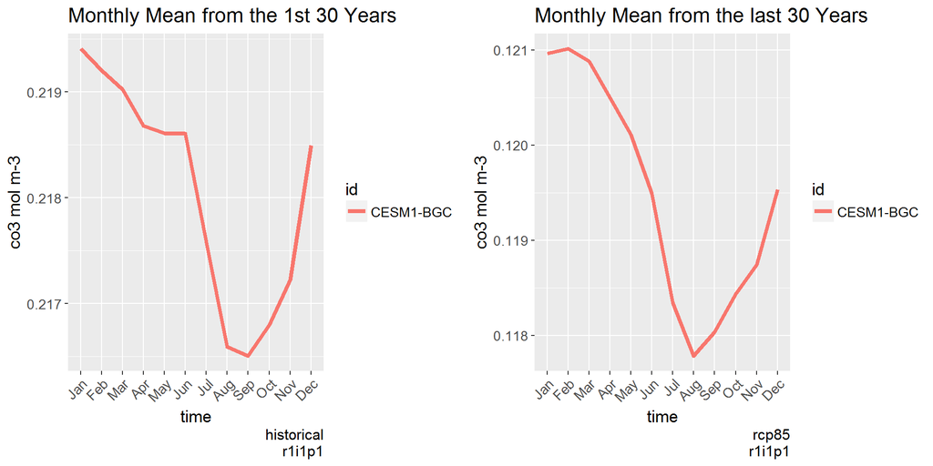

### 4. d. Monthly Amplitude CO3

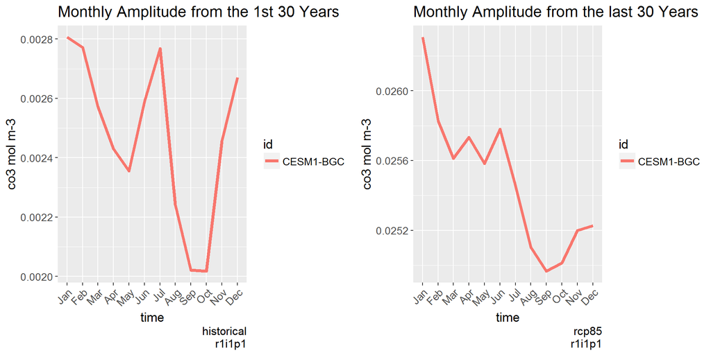

Amplitude mean and sd table

| ensemble | experiment | model | mean | sd |
| --- | --- | --- | --- | --- |
| r1i1p1 | historical | CESM1-BGC | 0.0024753 | 0.0002749 |

| ensemble | experiment | model | mean | sd |
| --- | --- | --- | --- | --- |
| r1i1p1 | rcp85 | CESM1-BGC | 0.025484 | 0.0003991 |

### 4. e. Monthly Mean tos

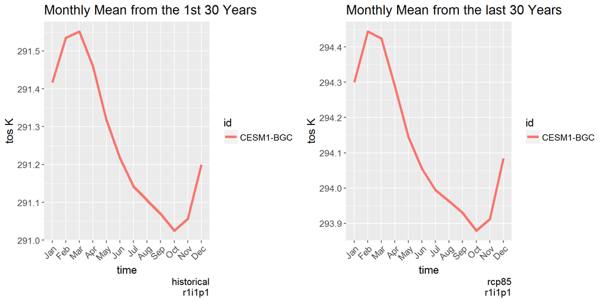

### 4. f. Monthly Amplitude tos

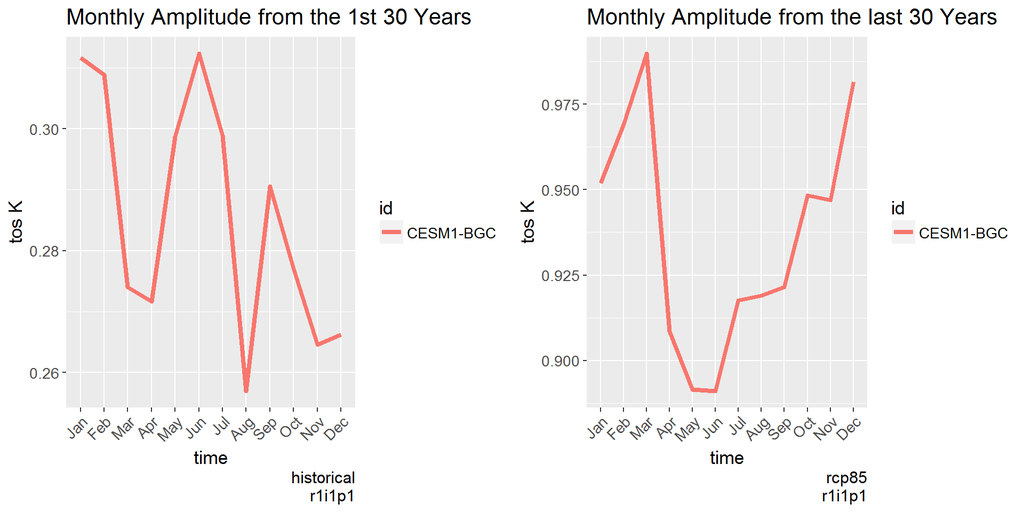

Amplitude mean and sd table

| ensemble | experiment | model | mean | sd |
| --- | --- | --- | --- | --- |
| r1i1p1 | historical | CESM1-BGC | 0.285965 | 0.0198548 |

| ensemble | experiment | model | mean | sd |
| --- | --- | --- | --- | --- |
| r1i1p1 | rcp85 | CESM1-BGC | 0.9363988 | 0.0332957 |

# 5. Linear Trends

### Tables

Table of counts for the non-0 linear trends.

| experiment | month | Yes |
| --- | --- | --- |
| historical | annual | 30 |
| historical | April | 30 |
| historical | August | 30 |
| historical | December | 30 |
| historical | February | 30 |
| historical | January | 30 |
| historical | July | 30 |
| historical | June | 30 |
| historical | March | 30 |
| historical | May | 30 |
| historical | November | 30 |
| historical | October | 30 |
| historical | September | 30 |
| rcp85 | annual | 36 |
| rcp85 | April | 36 |
| rcp85 | August | 36 |
| rcp85 | December | 36 |
| rcp85 | February | 36 |
| rcp85 | January | 36 |
| rcp85 | July | 36 |
| rcp85 | June | 36 |
| rcp85 | March | 36 |
| rcp85 | May | 36 |
| rcp85 | November | 36 |
| rcp85 | October | 36 |
| rcp85 | September | 36 |

Table of counts of trends with significant p values (p <= 0.005)

| experiment | month | No | Yes |
| --- | --- | --- | --- |
| historical | annual | 1 | 29 |
| historical | April | 1 | 29 |
| historical | August | 1 | 29 |
| historical | December | 1 | 29 |
| historical | February | 1 | 29 |
| historical | January | 1 | 29 |
| historical | July | 1 | 29 |
| historical | June | 1 | 29 |
| historical | March | 1 | 29 |
| historical | May | 1 | 29 |
| historical | November | 1 | 29 |
| historical | October | 1 | 29 |
| historical | September | 1 | 29 |
| rcp85 | annual | NA | 36 |
| rcp85 | April | NA | 36 |
| rcp85 | August | NA | 36 |
| rcp85 | December | NA | 36 |
| rcp85 | February | NA | 36 |
| rcp85 | January | NA | 36 |
| rcp85 | July | NA | 36 |
| rcp85 | June | NA | 36 |
| rcp85 | March | NA | 36 |
| rcp85 | May | NA | 36 |
| rcp85 | November | NA | 36 |
| rcp85 | October | NA | 36 |
| rcp85 | September | NA | 36 |

### 5. a. Annual Normalized Slope Box Plot

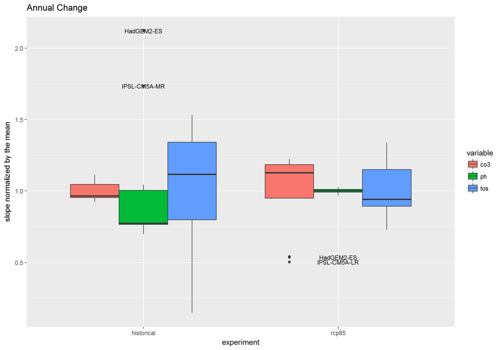

### 5. b. Monthly Normalized Slope Box Plots

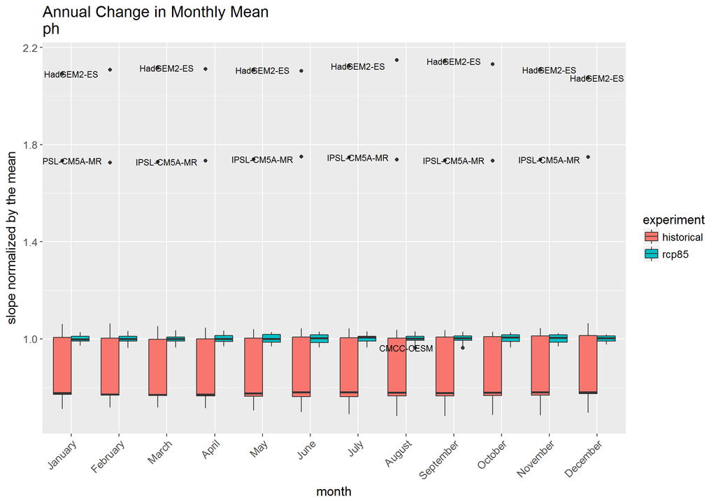

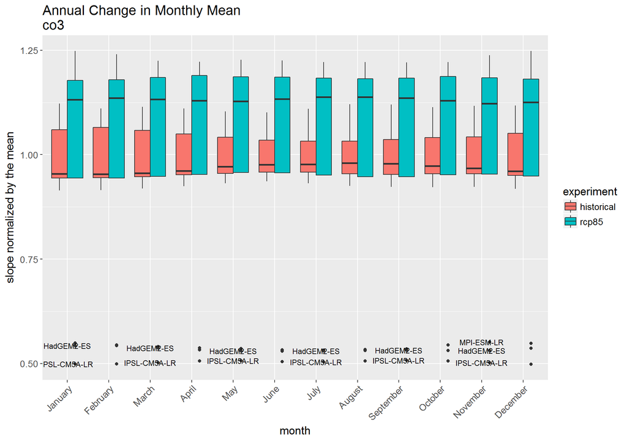

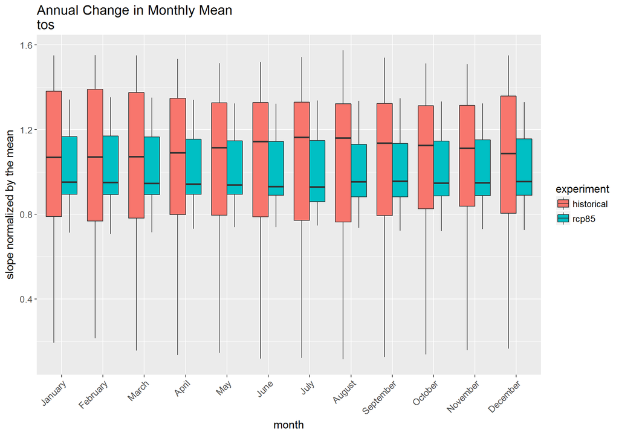

The End